# Lab 2: Visualizing and Mapping Movement Data

[EFB 796: Techniques in Movement Ecology](https://eligurarie.github.io/MovementEcologyBook/EFB796/)

Elie Gurarie (w/ Nicki Barbour)

August 28, 2025

Visualizing data is an important step in the data processing and analysis stages.

Learning how to visualize your data correctly can help you catch errors in your code, outliers in your data, and interesting patterns that will inform your analysis choices.

Visualization can be done with Base R plotting - which provides more control - or the `ggplot2` R package - which is excellent for exploratory analysis and complex plots in one line of code. We’ll also load the `sf` package.

```r
library(ggplot2)
library(sf)
```

## Base R

We can use base R to specify a “fancy” plot showing each of our tracks in multiple dimensions, including latitude/longitiude, latitude versus time, and longitude versus time.

Note that using a geographic coordinate system (GCS) with units in angular degrees (lat/lon) can be useful for mapping and observing patterns in the data but that direct, measurable comparisons can only be made with a projected coordinate system (PCS), where the units are in measurable units (e.g., meters). We will demonstrate how to work with projected coordinates in the next lab.

*Note*: You may find this online resource on [Plotting with Base R](https://bookdown.org/rdpeng/exdata/the-base-plotting-system-1.html) useful if you are unfamiliar with the `plot` function and its various arguments.

We start by loading our clean and processed data files:

```r
load("data/elk_processed.rda")
is(elk_gps)
```

```
## [1] "data.frame" "list"       "oldClass"   "vector"
```

```r
is(elk_sf)
```

```
## [1] "sf"       "oldClass"
```

Recall that this contains `elk_gps` and `elk_sf`. Because there are so many elk in this example, we will reduce the data to the first 9 animals:

```r
str(elk_gps)
```

```
## 'data.frame':    138425 obs. of  4 variables:
##  $ datetime: POSIXct, format: "2001-12-13 07:01:00" "2001-12-13 09:01:00" ...
##  $ lon     : num  -116 -116 -116 -116 -116 ...
##  $ lat     : num  52.1 52.1 52.1 52.1 52.1 ...
##  $ id      : Factor w/ 31 levels "4049","GP1","GP2",..: 1 1 1 1 1 1 1 1 1 1 ...
```

```r
elk_gps <- elk_gps |> subset(id %in% levels(id)[1:9])
elk_sf <- elk_sf |> subset(id %in% levels(id)[1:9])
```

### In space

Let’s make a basic R plot of the track for the individual, `4049`:

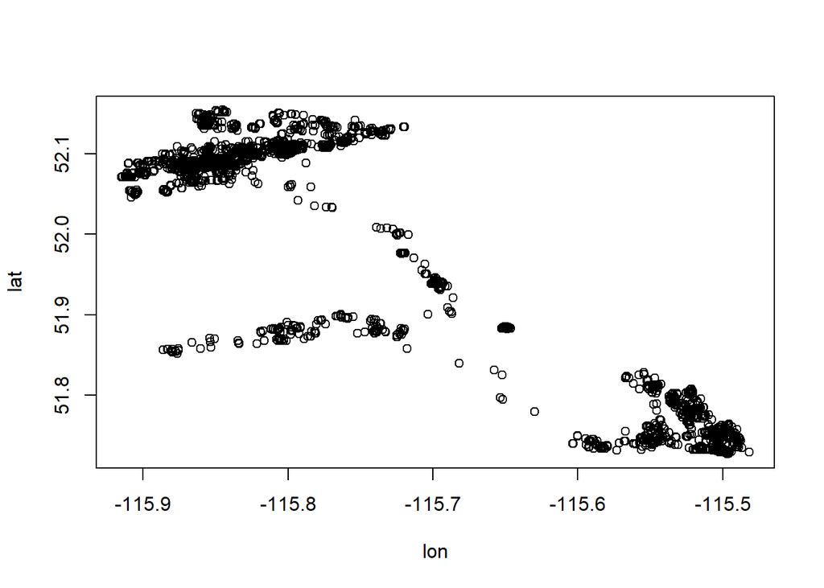

```r
E4049 <- subset(elk_gps, id == "4049")
with(E4049, plot(lon, lat))
```

We can “connect the points”:

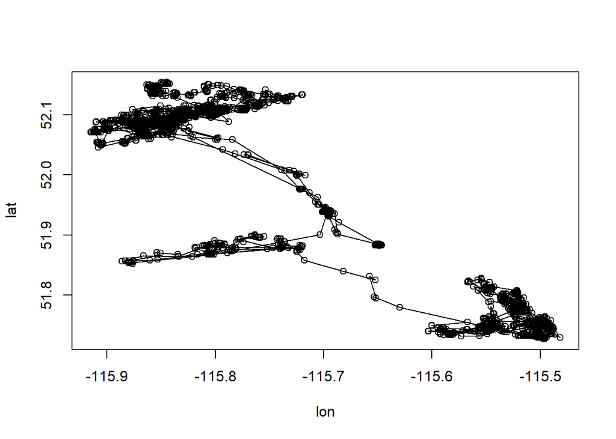

```r
with(E4049, plot(lon, lat, type = "o"))
```

### In space - metric

> **Extra- in metric:** Since we have a correctly projected version of this animal, we could also extract the coordinates in an appropriate UTM format, to get a sense of the distance traveled. This cute piece of code finds the UTM zone from any longitude:

```r
long2UTM <- function(long) (floor((long + 180)/6) %% 60) + 1
```

> In our case, the UTM zone will be:

```r
long2UTM(-115)
```

```
## [1] 11
```

> Now, we just need to find the EPSG code for that UTM zone. It is (from quick searching): 32611.  
> So - to draw this in metric units:

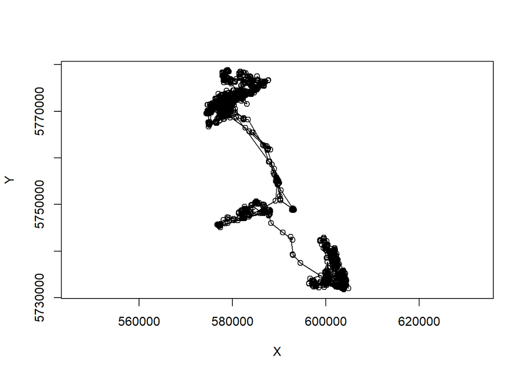

```r
E4049.xy <-  elk_sf |> subset(id == 4049) |> st_transform(32611) |> st_coordinates()
plot(E4049.xy, asp = 1, type = "o")
```

> This is nice, because it shows that the movement was *mainly* north-south. These are so useful, we might want to add them to our original data:

```r
require(sf)
elk_gps <-  elk_gps |> data.frame(elk_sf |> st_transform(32611) |> st_coordinates())
str(elk_gps)
```

```
## 'data.frame':    42194 obs. of  6 variables:
##  $ datetime: POSIXct, format: "2001-12-13 07:01:00" "2001-12-13 09:01:00" ...
##  $ lon     : num  -116 -116 -116 -116 -116 ...
##  $ lat     : num  52.1 52.1 52.1 52.1 52.1 ...
##  $ id      : Factor w/ 31 levels "4049","GP1","GP2",..: 1 1 1 1 1 1 1 1 1 1 ...
##  $ X       : num  581853 582145 580276 580023 581917 ...
##  $ Y       : num  5775515 5774799 5772376 5772614 5772259 ...
```

### In space and time

I (EG) find the following plot, which I’ve always called a “scan track” to be very useful because it lets us see what’s going on in both space AND time.

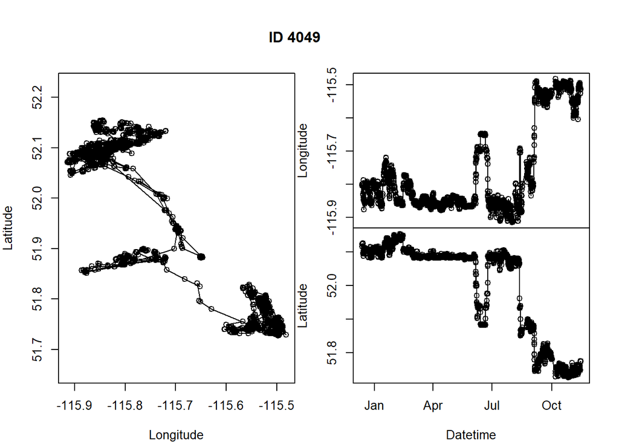

```r
layout(rbind(c(1,2), c(1,3)))
with(E4049, {
  plot(lon, lat, asp = 1, type="o", ylab="Latitude", xlab="Longitude")
  plot(datetime, lon, type="o", xaxt="n", ylab="Longitude", xlab="")
  plot(datetime, lat, type="o", ylab="Latitude", xlab="Datetime")
  title(paste("ID", id[1]), outer = TRUE)
})
```

We can also write our own little function to apply this plot to several individuals at once.

> For more information/help on writing functions in R, check out this helpful online resource, [Writing Functions in R](https://dept.stat.lsa.umich.edu/~jerrick/courses/stat701/notes/functions.html).

```r
scan_track <- function(dataframe, x = "lon", y = "lat",
                             time = "datetime", id = "id", ...){
  par(mar = c(0,4,0,0), oma = c(4,0,5,2), xpd=NA)
  layout(rbind(c(1,2), c(1,3)))
  with(dataframe, {
    plot(get(x), get(y), asp = 1, type="o", ylab=y, xlab=x, ...)
    plot(get(time), get(x), type="o", xaxt="n", ylab=y, xlab="", ...)
    plot(get(time), get(y), type="o", ylab=y, xlab=time, ...)
    title(paste("ID", id[1]), outer = TRUE)
  })
}
```

There are a few tricks in this function that make it extra flexible. For example, this is the default:

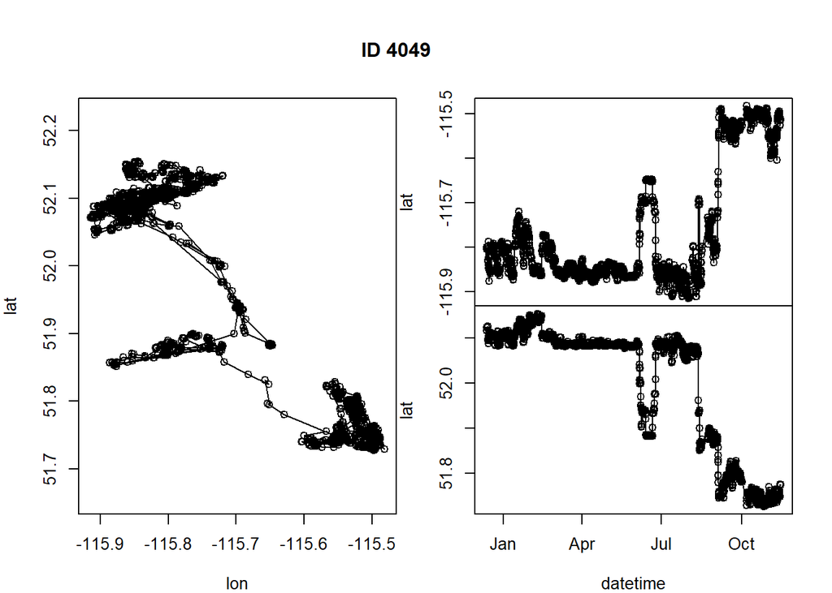

```r
scan_track(elk_gps |> subset(id == id[1]))
```

But this is looking UTM’s, and with fun colors:

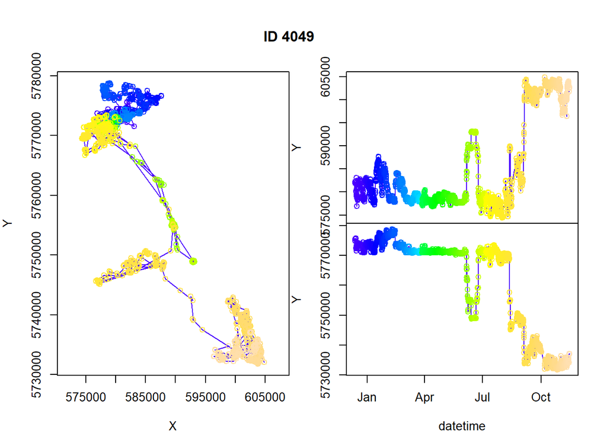

```r
myelk <- elk_gps |> subset(id == id[1])
scan_track(myelk, x = "X", y = "Y",
                 col = topo.colors(nrow(myelk)))
```

This plot is very helpful for seeing what the elk is doing.

### Scan tracks across indviduals

We can use the `plyr` package with the `d_ply` function to apply our new function grouped by a variable of interest, here each individual. This function will simply return the output of the function used (see also `ddply`, which we will use later to return a dataframe based on a function’s output).

> *Note*: plyr and dplyr do not “play nice” with each other. You need to load the dplyr package AFTER the plyr package to avoid conflicts and function masking. We can use the `detach` function to unload our dplyr package, then use the `library` function to load the plyr and dplyr packages, consecutively. If you see that a particular function is “masked” you can use the package name and “:” before the name of a particular function from a particular package to ensure that masking (which happens when you have functions of the same name in two packages that are loaded) does not occur (e.g., `dplyr::select()`).

The following code generates the figure above for the first 5 elk, for example:

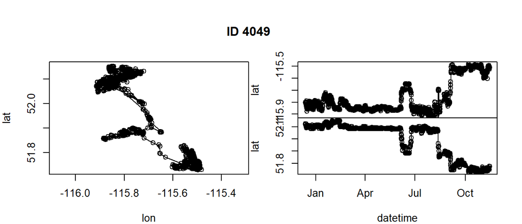

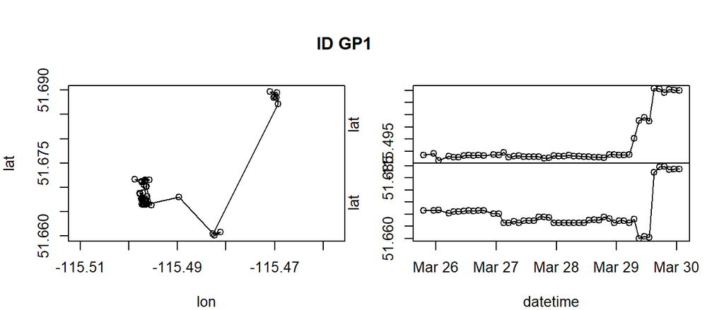

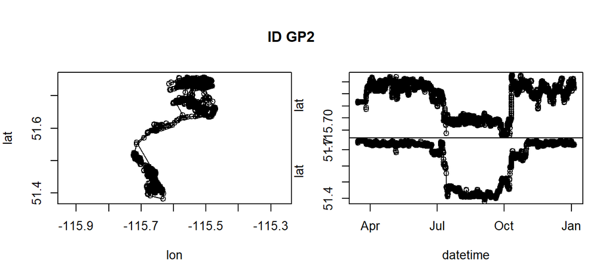

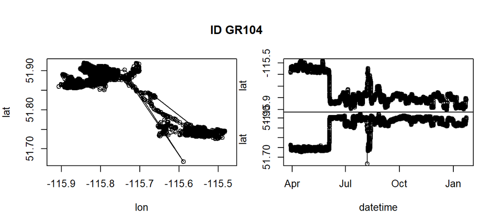

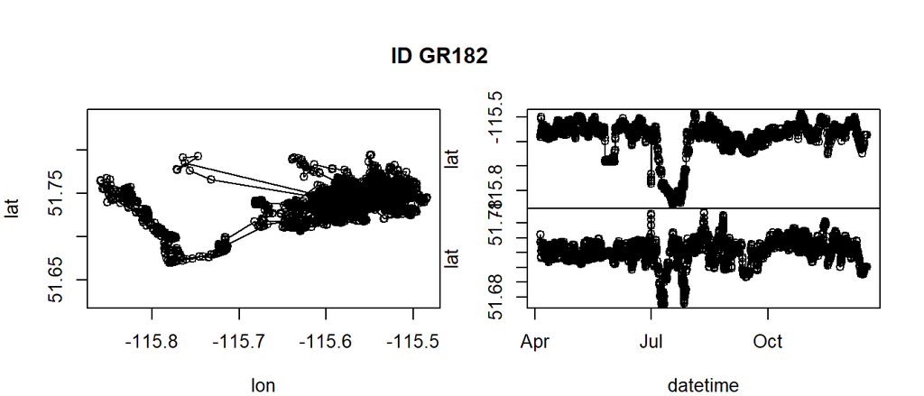

```r
require(plyr)
elk_gps |> subset(id %in% levels(id)[1:5]) |> d_ply("id", scan_track)
```

## Using `ggplot`

The `ggplot` function takes arguments for the data object to be plotted, the x and y axis variables to be plotted (within the `aes()` function), a variety of additional aesthetic arguments (e.g., color or linewidth), and additive functions that define the plot type.

```r
library(ggplot2)
```

For more help with plotting with ggplot, check out this helpful online resource, [ggplot2 with the tidyverse](https://ggplot2.tidyverse.org/).

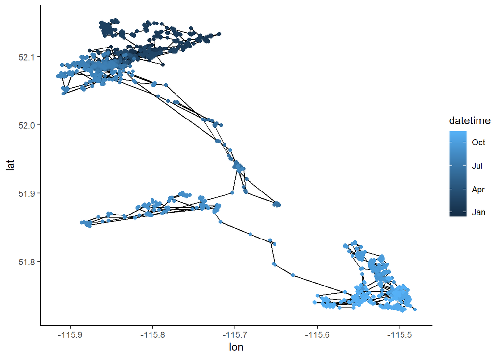

```r
ggplot(data = E4049, aes(x = lon, y = lat)) +
   geom_path(size = 0.5) +
   geom_point(aes(color = datetime)) + theme_classic()
```

Now let’s visualize all individuals at once, using the additional `facet_wrap` function to facet or group our plots by each elk id. The “scale = ‘free’” argument allows each plot to have its own intuitive x and y axis limits (“scale=‘fixed’ does the opposite).

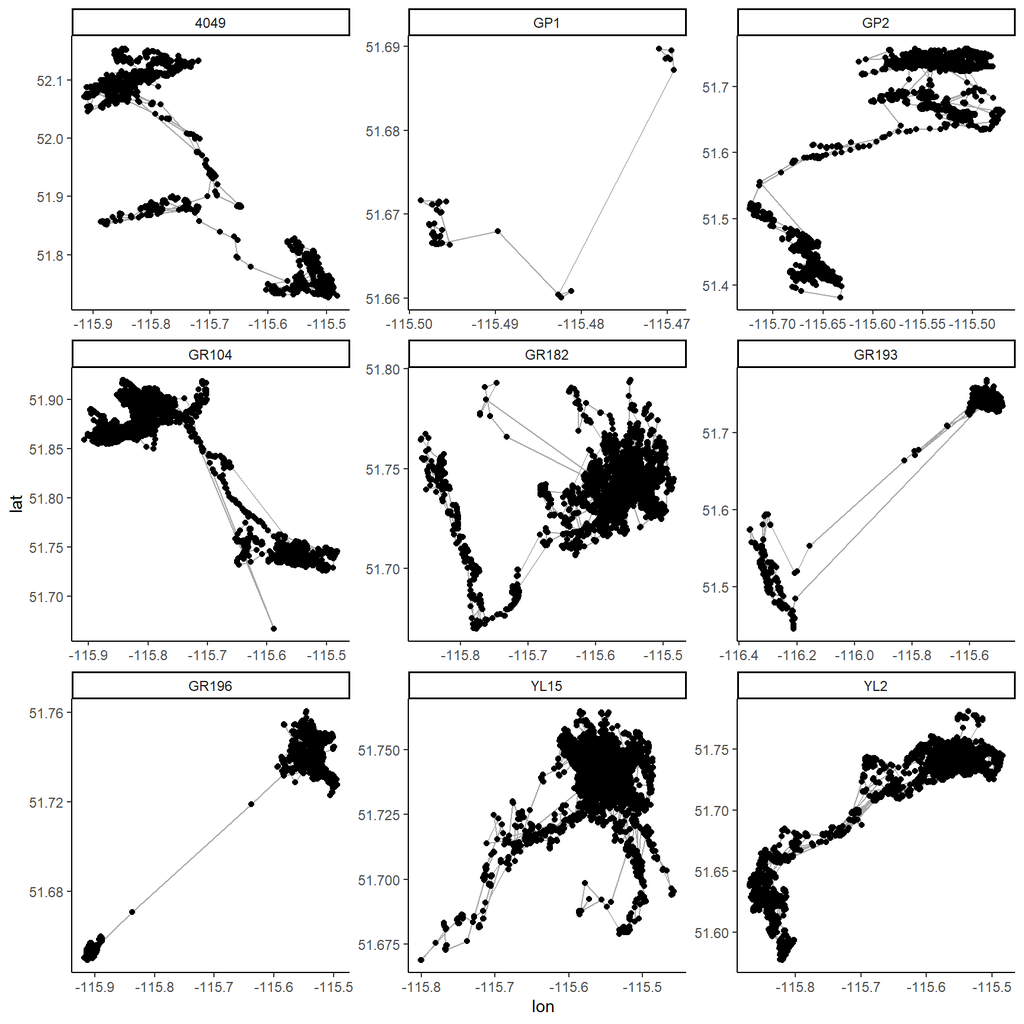

```r
ggplot(data = elk_gps, aes(x = lon, y = lat)) +
  geom_path(size = 0.5, color = "darkgrey") +
  geom_point() +
  theme_classic() +
  facet_wrap(~id, scale="free", ncol=3)
```

Or - also useful - all together. Note the `col` and `group` arguments:

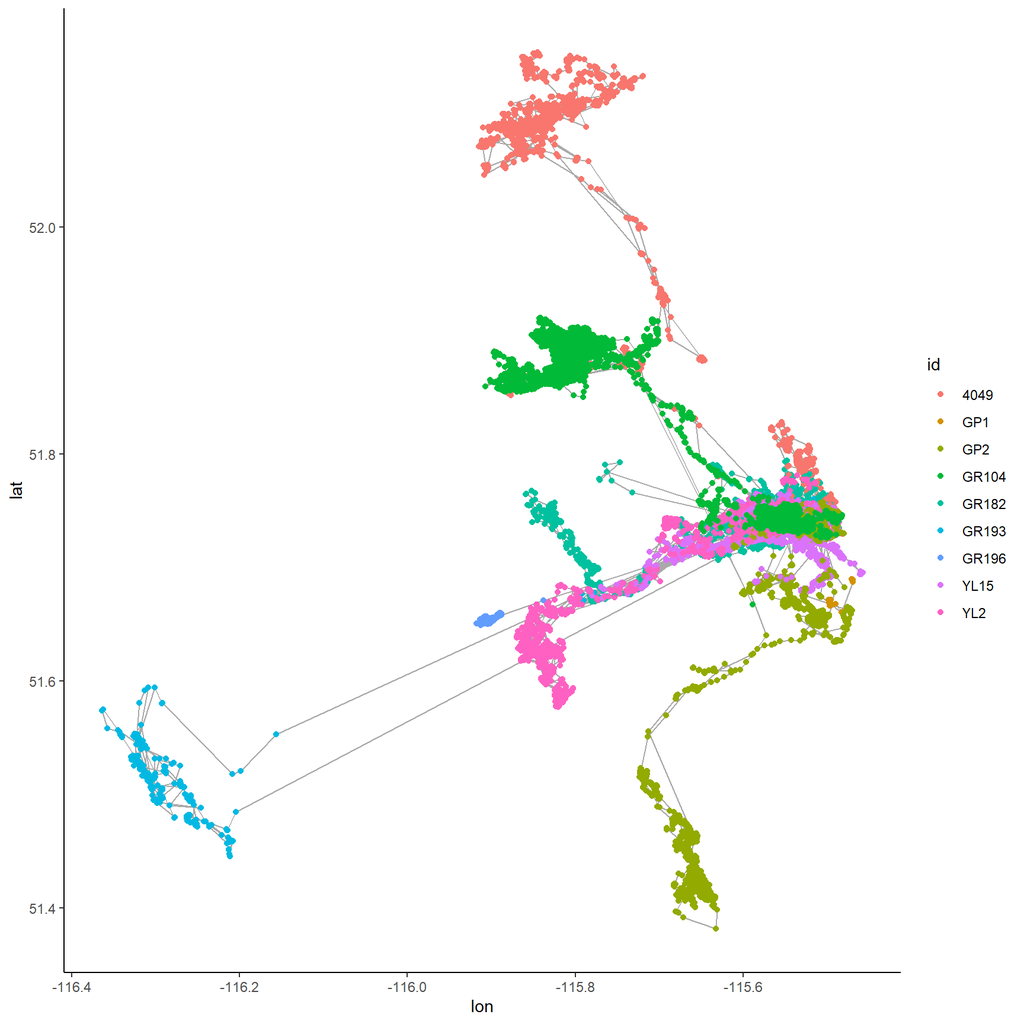

```r
ggplot(data = elk_gps, aes(x = lon, y = lat, col = id, group =id)) +
  geom_path(size = 0.5, color = "darkgrey") +
  geom_point() +
  theme_classic()
```

We can also visualize latitude or longitude versus datetime. This can be especially helpful for identifying interesting behavioral patterns in animal movement (e.g., residency vs transiting), which can inform your choice of analysis method later on.

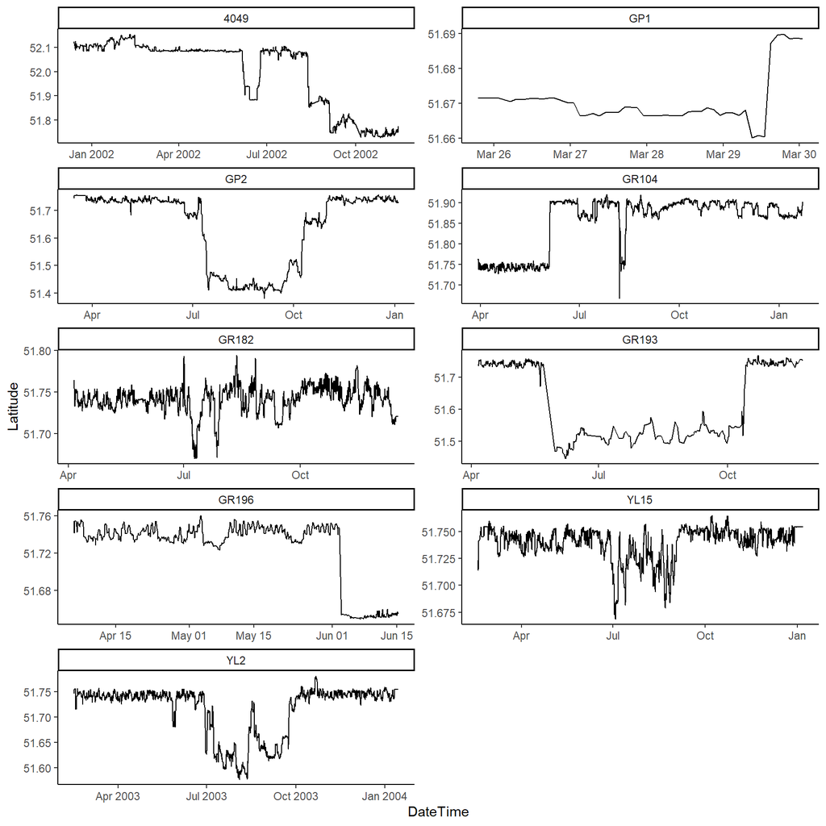

```r
ggplot(data = elk_gps, aes(x = datetime, y = lat)) +
  geom_path(size = 0.5) +
  xlab("DateTime") + ylab("Latitude") +
  theme_classic() +
  facet_wrap(~id, scale="free", ncol = 2)
```

We see a nice variety of migratory behavior.

## Spatial Plots and Mapping

### Base R plots

`sf` objects can be plotted by their attributes using the `plot` Base R function.

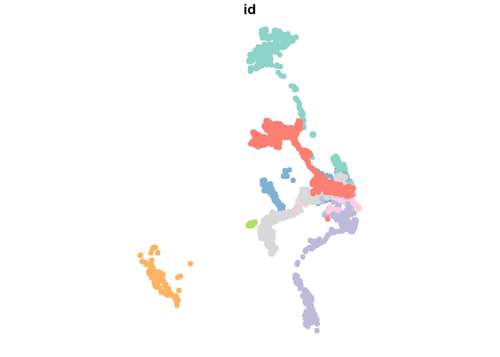

```r
plot(elk_sf[,"id"], pch = 19)
```

Without a background map, this plot is not very informative.

There are, however, some terrific tools for loading available spatially explicit & georeferenced maps, aka *basemaps*.

### Basemaps

In the `basemaps` package is an excellent tool for making maps. It downloads and caches map tiles from different providers and works seamlessly with base R plotting.

Load the package:

```r
require(basemaps)
```

Next, important to set the spatial limits of the data. You can extract these from the spatial data:

```r
elk_bbox <- st_bbox(elk_sf)
elk_bbox
```

```
##       xmin       ymin       xmax       ymax
## -116.36404   51.38134 -115.45784   52.15410
```

We’ll make it a little wider like so:

```r
elk_bbox <- st_bbox(elk_sf) + c(-.25,-.25,.25,.25)
```

```r
elk_basemap <- basemap_raster(ext = elk_bbox,
                              map_service = "esri",
                              map_type = "world_imagery",
                              zoom = 10)
```

```
## Loading basemap 'world_imagery' from map service 'esri'...
```

The `world_imagery` tiles from the `esri` service is one of many options, listed in the `get_maptypes()` function. The ouput - the basemap - is a `raster` - a form of spatial data that essentially maps to a matrix grid of georeferenced locations. See the excellent chapter by Nicki [here](https://eligurarie.github.io/MovementEcologyBook/part2_data_and_manipulations/spatial_data_in_R.html).

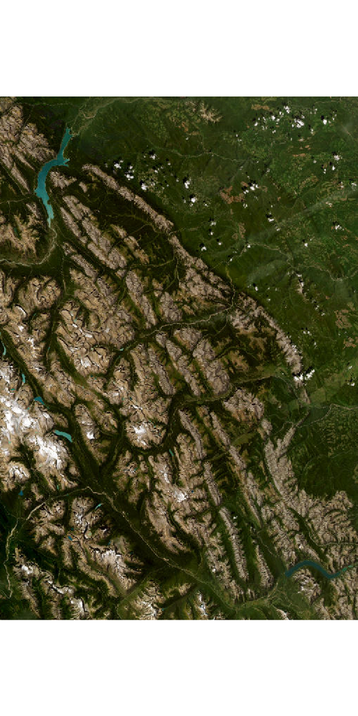

```r
require(raster)
plotRGB(elk_basemap)
```

The elk data can be overlaid on this map by simply adding points (or lines) on top. VERY IMPORTANT - you have to *transform* the CRS of the movement data to match the data of the raster:

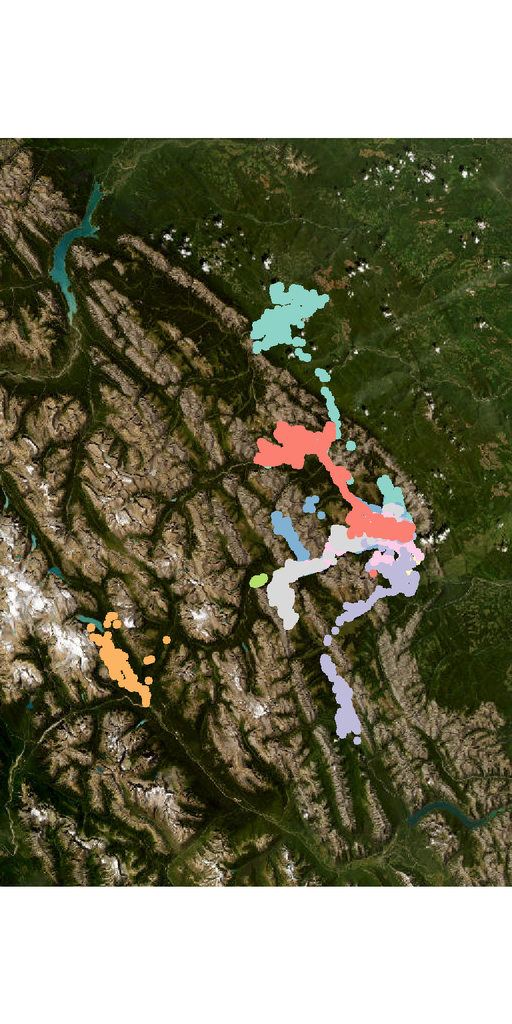

```r
plotRGB(elk_basemap)
plot(elk_sf[,"id"] |> st_transform(crs(elk_basemap)),
     add = TRUE, pch = 19, cex = 0.8)
```

Or, then, you can add lines in whatever way you like.

### mapping with `ggplot` and `ggspatial`

The same basemap can be mapped with `ggplot`. The key pieces here are the `layer_spatial`, where you specify the baseplot, and the `geom_sf` which is the “geometry” which generates nice maps.

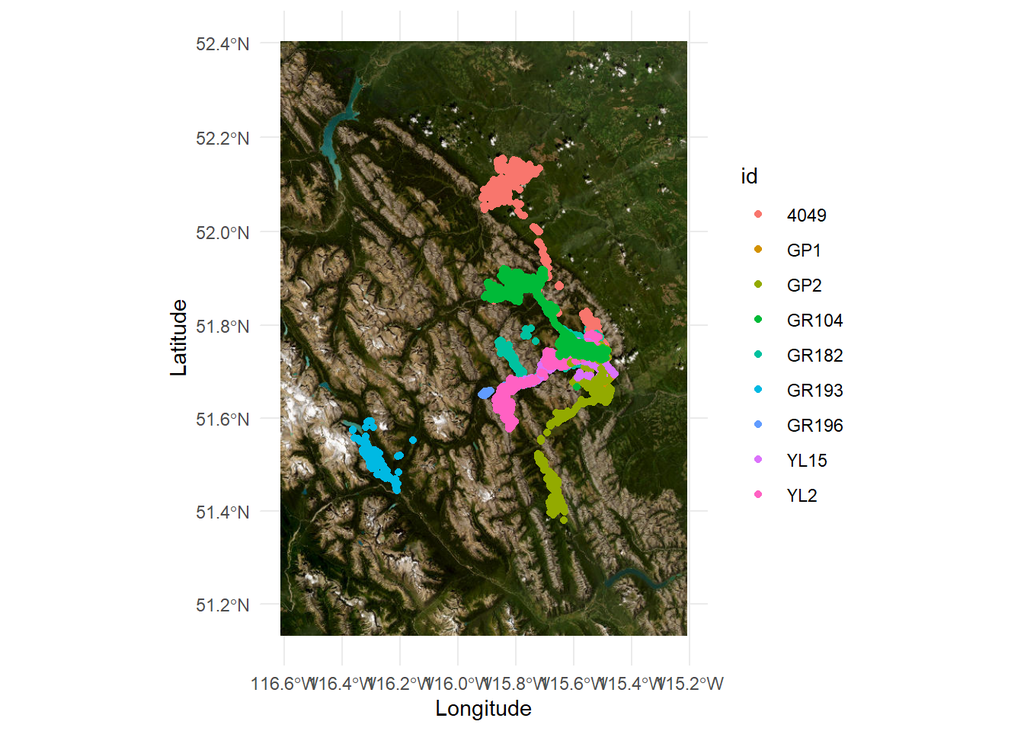

```r
require(ggspatial)
ggplot() +
  layer_spatial(elk_basemap) +  # Plot the raster basemap
  geom_sf(data = elk_sf, aes(col = id)) +  # Add elk data
  labs(x = "Longitude", y = "Latitude") +
  theme_minimal()
```

This has some advantages of labeling, etc.

### Using `ggspatial`

The `ggspatial` package, can accesses those basemaps, such that there is a way to do all the steps above in a single workflow.

The `annotation_map_tile` function allows you to specify a background map type (“type=”) and zoom level (`zoom=`, where a higher zoom is a higher resolution but may take longer to render). You can run the code `rosm::osm.types` to see all the different map tile types available. We will use the “Open Street Map” (osm) one. You can then add on your other, regular ggplot functions, such as `geom_sf` and theme options.

Here’s a fully-featured map with some nice map features, such as a scale bar (function `annotation_scale()`) and a north arrow (function `annotation_north_arrow()`, with arguments for specifying height, width, padding dimensions). You can also specify nicer axis labels and breaks using the `scale_y_continuous` and `scale_x_continuous` functions.

```r
elk_basemap <- ggplot() +
  annotation_map_tile(type = 'osm', zoom = 10) +
  annotation_scale() +
  annotation_north_arrow(height=unit(0.5,"cm"), width=unit(0.5,"cm"),
                         pad_y = unit(1,"cm")) +
  shadow_spatial(elk_bbox) +
  ylab("Latitude") + xlab("Longitude")
```

Note - that is faster and sometime more attractive to plot not points but lines. To do that with a simple feature, you have to (a) group the points, (b) combine them `summarize`, and then (c) “cast” them into `LINESTRINGS` with `st_cast`.

```r
require(dplyr)
elk_tracks <- elk_sf |>
  group_by(id) |>
  summarize(do_union=FALSE) |>
  st_cast("LINESTRING")
```

Note that `elk_tracks` is a simple feature with one row per animal, and each row contains a complete geometry of lines:

```r
elk_tracks
```

```
## Simple feature collection with 9 features and 1 field
## Geometry type: LINESTRING
## Dimension:     XY
## Bounding box:  xmin: -116.364 ymin: 51.38134 xmax: -115.4578 ymax: 52.1541
## Geodetic CRS:  WGS 84
## # A tibble: 9 × 2
##   id                                                                    geometry
##   <fct>                                                         <LINESTRING [°]>
## 1 4049  (-115.8043 52.1241, -115.8003 52.11762, -115.8281 52.09611, -115.8318 5…
## 2 GP1   (-115.4965 51.67146, -115.4958 51.6715, -115.4987 51.67166, -115.4969 5…
## 3 GP2   (-115.5874 51.74308, -115.5808 51.74733, -115.583 51.75446, -115.5828 5…
## 4 GR104 (-115.5838 51.7598, -115.5811 51.76231, -115.581 51.76254, -115.5809 51…
## 5 GR182 (-115.5732 51.76429, -115.5829 51.75458, -115.583 51.75437, -115.5831 5…
## 6 GR193 (-115.5096 51.73482, -115.5321 51.73963, -115.5442 51.74063, -115.5691 …
## 7 GR196 (-115.5827 51.7544, -115.5548 51.74159, -115.5828 51.75447, -115.5829 5…
## 8 YL15  (-115.6957 51.72338, -115.7116 51.71387, -115.6852 51.71495, -115.7015 …
## 9 YL2   (-115.5788 51.74599, -115.5827 51.75454, -115.5828 51.75464, -115.5829 …
```

The map above with lines looks like this:

[output not shown]

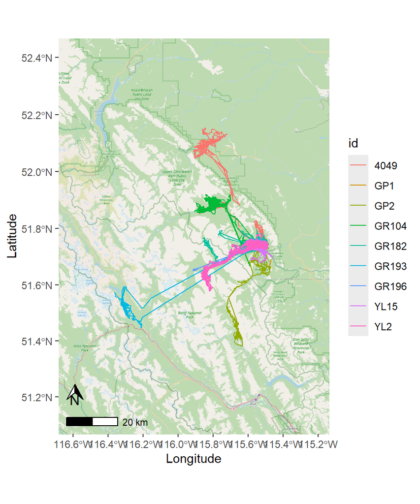

```r
elk_basemap +
  geom_sf(data=elk_tracks, aes(col = id))
```

### Exporting Static Map

To export your map, you could do so by sandwhiching your map code between the file type function you want the image to be saved as (e.g., `jpeg` or `png`) and the function `dev.off()`.

```r
jpeg(file="ElkMap.jpg", units="in", width=4, height=7,res=300)
  elk_basemap +
    geom_sf(data=elk_sf, aes(col = id))
dev.off()
```

## mapview

Interactive mapping in R with the `mapview` R package is a useful way to visualize and engage with spatial data. You’ve seen this with individual animals, but it is even faster once they are turned into “tracks”, specifying to color the tracks by different ids with the `zcol` argument.

```r
library(mapview)
mapview(elk_tracks, zcol="id")
```

[interactive chart not shown]

Note that the `mapview` function can plot any spatial data and has a variety of additional controls/arguments available (see [Advanced Mapview Controls](https://r-spatial.github.io/mapview/articles/mapview_02-advanced.html) for more options and examples).